# **Data Analysis Course Outline**

**Below are the tentative weekly topics to be covered.** **Also included are selected R functions that we will learn how to use.**

**Further, there are examples of some code and its output for each week** **to give you an rough idea about what these topics are covering.**

**We will learn all of this as we go, so don’t be scared by anything…it get pretty easy once you have a foundation.**

**This document was constructed entirely within R as an R-markdown (Rmd) file.**

The complete code for this document can be found online [HERE](https://raw.githubusercontent.com/gzahn/Data_Course/master/Rough_Course_Outline.rmd)

All course documents and data sets can be found on the [Course GitHub repository](https://github.com/gzahn/Data_Course)

### WEEK 1

- Why use code!?
- INSTALL R / R-studio
- Familiarize R-studio functions and layout
- Where to look for help

```r
# Functions covered (parital list):
help()
```

### WEEK 2

- Assigning things to objects
- Get familiar with object types and basic functions
  - values, vectors, lists
  - data frames and matrices
  - boolean, character, numeric, POSIXct
- Accessing elements of objects
- Boolean evaluations
- Data-type conversions

```r
# Functions covered (parital list):
=       <-      ->
class()
data.frame()  as.factor()   as.numeric()    as.character()    as.POSIXct()    as.matrix()
==    <   >   <=    >=
+     -   *   /
which()   signif()    ceiling()     floor()       round()
c()       list()      cbind()       rbind()       sum()         mean()        sd()
```

```r
vector = c(1,2,3,4,5,6,7,8,9,10) # assign a series of numbers to an object called "vector"
mean(vector) # calculate the mean of the numbers in that object
```

```
## [1] 5.5
```

### WEEK 3

- Importing data
- Useful data formats
- Data structure and attributes
- Summary stats and basic visualizations
- Exploring data
  - Sorting, Transposing, Sampling
  - heatmaps, boxplots, barcharts, scatterplots, histograms

```r
# Functions covered (parital list):
read.csv()        read.delim()
str()             dim()             names()           attributes()          head()
summary()         min()             max()             range()               quantile()
hist()            boxplot()         barplot()         plot()                heatmap()
sample()          t()               sort()            tail()                var()
```

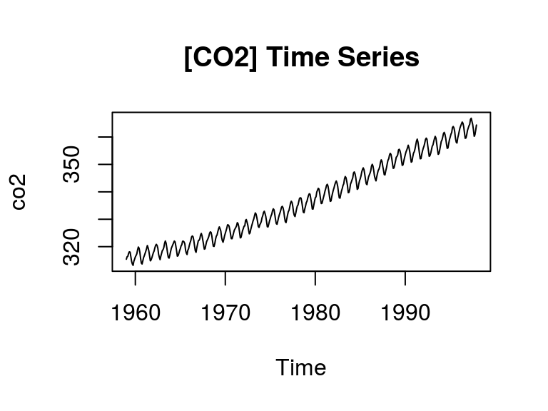

```r
plot(co2, main = "[CO2] Time Series") # make a simple plot of the data in the object called "co2"
```

```r
summary(co2) # generate statistical summaries of those data
```

```
##    Min. 1st Qu.  Median    Mean 3rd Qu.    Max.
##   313.2   323.5   335.2   337.1   350.3   366.8
```

### WEEK 4

- Finding/Installing/Loading packages
- Extending functionality of R
- Subsetting and manipulating raw data
- Output options

```r
# Functions covered (parital list):
install.packages()
library()
cor()
write.table()       sink()        tiff/jpeg/png() / dev.off()
```

```r
data # show original data
```

```
##    Plant        Type  Treatment conc uptake
## 1    Qn1      Quebec nonchilled   95   16.0
## 43   Mn1 Mississippi nonchilled   95   10.6
## 44   Mn1 Mississippi nonchilled  175   19.2
## 2    Qn1      Quebec nonchilled  175   30.4
## 3    Qn1      Quebec nonchilled  250   34.8
## 45   Mn1 Mississippi nonchilled  250   26.2
## 4    Qn1      Quebec nonchilled  350   37.2
## 46   Mn1 Mississippi nonchilled  350   30.0
## 5    Qn1      Quebec nonchilled  500   35.3
## 47   Mn1 Mississippi nonchilled  500   30.9
```

```r
data[data$Type == "Quebec",] # subset data to only include samples from "Quebec"
```

```
##   Plant   Type  Treatment conc uptake
## 1   Qn1 Quebec nonchilled   95   16.0
## 2   Qn1 Quebec nonchilled  175   30.4
## 3   Qn1 Quebec nonchilled  250   34.8
## 4   Qn1 Quebec nonchilled  350   37.2
## 5   Qn1 Quebec nonchilled  500   35.3
```

```
  Skills Test 1:

  * Import data set
  * Convert elements to new data type
  * Subset based on values
  * Calculate summary statistics
  * Create basic summary figures
  * Export summary statistics to text file
```

### WEEK 5

- Data estimations
  - point estimates
  - interval estimates
- Hypothesis testing / Model fitting
  - t-test (paired/unpaired)
  - chi-square
  - ANOVA
  - LM/GLM

```r
# Functions covered (parital list):
lm()        glm()         aov()
t.test()    chisq.test()
```

```r
ANOVA = aov(uptake ~ conc, data = CO2) # define an analysis of variance model CO2 uptake by plants, predicted by CO2 concentration in atmosphere
summary(ANOVA) # show summary ANOVA table and P-value
```

```
##             Df Sum Sq Mean Sq F value   Pr(>F)
## conc         1   2285  2285.0   25.25 2.91e-06 ***
## Residuals   82   7422    90.5
## ---
## Signif. codes:  0 '***' 0.001 '**' 0.01 '*' 0.05 '.' 0.1 ' ' 1
```

### WEEK 6

- Experimental design
- Common designs and analysis options
- Quantitative vs qualitative data
- Probability distributions
- Fitting distributions
- Type I and Type II errors
- Post-hoc tests

```r
# Packages used (partial list):
fitdistrplus
MASS
# Functions covered (parital list):
plotdist()      descdist()
fitdist()       denscomp()        cdfcomp()
TukeyHSD()
```

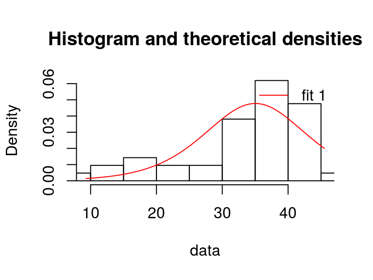

```r
# Fit CO2 uptake data from Quebec samples to a logistic probability distribution
fit.logistic = fitdist(CO2$uptake[CO2$Type == "Quebec"], distr = "logis")
denscomp(fit.logistic) # Plot comparison between logistic distribution and actual data
```

### WEEK 7

- Non-parametric alternatives
- Mann-Whitney-Wilcoxin
- Kruskal-Wallace
- Apply functions

```r
# Packages used (partial list):

# Functions covered (parital list):
wilcox.test()     kruskal.test()

apply()     sapply()      lapply()      tapply()
```

```r
data[,4:5] # look at columns 4 and 5 from object called "data"
```

```
##    conc uptake
## 1    95   16.0
## 43   95   10.6
## 44  175   19.2
## 2   175   30.4
## 3   250   34.8
## 45  250   26.2
## 4   350   37.2
## 46  350   30.0
## 5   500   35.3
## 47  500   30.9
```

```r
apply(data[,4:5], 2, sum) # Apply the 'sum' function to those columns
```

```
##   conc uptake
## 2740.0  270.6
```

### WEEK 8

- Other peoples’ data
- Principles of tidy data
- Intuitive manipulations and group functions
  - filter
  - arrange
  - select
  - mutate
  - group_by
  - summarize
  - %>%
- Tidy data transformations
  - gather
  - spread

```r
# Packages used (partial list):
dplr      plyr      tidyr
# Functions covered (parital list):
filter()      arrange()       select()        mutate()
group_by()    summarize()     %>%
gather()      spread()
```

```r
# Get specific summary data for defined groups from the object called "data" and save as object called "group.summaries"
group.summaries = data %>%
  group_by(Type) %>%
  summarize(Samples = n(), Mean.uptake = mean(uptake), Total.uptake = sum(uptake), StDev.uptake = sd(uptake))

as.data.frame(group.summaries) # display summary info for different locations (groups) as a data frame
```

```
##          Type Samples Mean.uptake Total.uptake StDev.uptake
## 1      Quebec       5       30.74        153.7     8.608020
## 2 Mississippi       5       23.38        116.9     8.501882
```

```
  Skills Test 2:

  * Import messy data
  * Convert to tidy format
  * Plot data distribution
  * Rearrange and mutate data set
  * Summary stats on grouped data
  * Test hypothesis / post-hoc tests
```

### WEEK 9

- Predicting data
- Intro to ggplot

```r
# Packages used (partial list):
ggplot2

# Functions covered (parital list):
predict()
qplot()
ggplot()
    aes()
```

```r
library(ggplot2) # load ggplot2 package

new.data = data.frame(conc = c(1500,2000)) # give new predictor values (CO2 concentration)
predicted = predict(ANOVA, newdata = new.data) # predict plant uptake for those values based on previous ANOVA model ... see Week 5
predicted # Look at predictions based on our ANOVA model
```

```
##        1        2
## 46.09617 54.96146
```

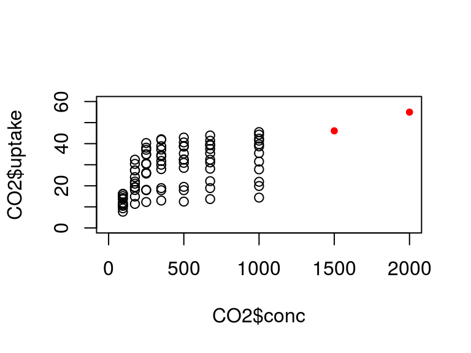

```r
plot(CO2$conc,CO2$uptake,xlim=c(0,2000),ylim=c(0,60)) # simple plot of CO2 data
points(x=c(1500,2000),y=predicted[1:2],pch=20,col="Red") # Add our predicted uptake values for higher CO2 concentrations in red
```

### WEEK 10

- Figure generation
- Figure export

```r
# Packages used (partial list):
ggplot2

# Functions covered (parital list):
ggplot()
geom_point()      geom_boxplot()      geom_bar()      geom_violin()
labs()            ggsave()
```

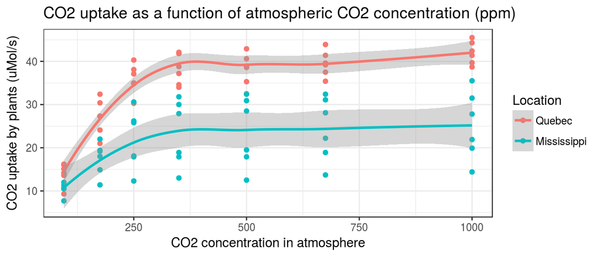

```r
library(ggplot2) # load ggplot2 package

# Create ggplot and save as abject called "CO2.plot"
CO2.plot = ggplot(CO2, aes(x=conc, y=uptake, col=Type))+
  geom_point() +
  geom_smooth(method = "loess") +
  labs(x="CO2 concentration in atmosphere", y="CO2 uptake by plants (uMol/s)") +
  ggtitle("CO2 uptake as a function of atmospheric CO2 concentration (ppm)") +
  theme_bw() +
  scale_color_discrete(name = "Location")

# Display plot
CO2.plot
```

### WEEK 11

- Figure generation continued

```r
# Packages used (partial list):
ggplot2
gridExtra

# Functions covered (parital list):
grid.arrange()
ggplot()
scale_*()
```

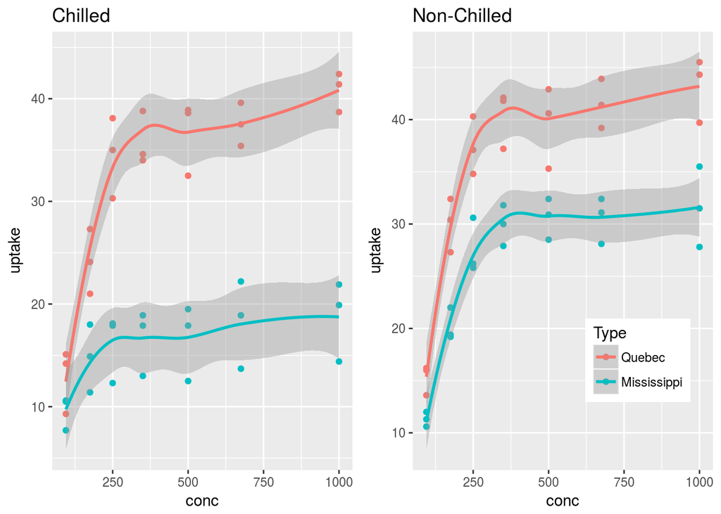

```r
# Make two separate plots - One for each temperature treatment
CO2.plot.1 = ggplot(CO2[CO2$Treatment == "chilled",], aes(x=conc, y=uptake, col=Type)) +
  geom_point() +
  geom_smooth(method = "loess") +
  ggtitle("Chilled") +
  theme(legend.position="none")

CO2.plot.2 = ggplot(CO2[CO2$Treatment == "nonchilled",], aes(x=conc, y=uptake, col=Type)) +
  geom_point() +
  geom_smooth(method = "loess") +
  ggtitle("Non-Chilled") +
  theme(legend.position=c(.75,.25))

# Combine the two plots into one image
grid.arrange(CO2.plot.1, CO2.plot.2, nrow = 1)
```

### WEEK 12

- Data standardization / normalization
- Ecology examples
  - Ordinations / NMDS
  - PermANOVA
  - Distance measures
  - Diversity measures

```r
# Packages used (partial list):
vegan

# Functions covered (parital list):
decostand()       rrarefy()         dist()        betadiver()
metaMDS()         adonis()          diversity()   betadisper()
```

```r
head(community_matrix)[,1:10] # Take a look at the community composition (observed counts) for different samples
```

```
##          Species_1 Species_2 Species_3 Species_4 Species_5 Species_6
## Sample_1       548       883       480       357        64       832
## Sample_2       218        67       815       726       974       740
## Sample_3         0       306       199       991       933       244
## Sample_4       792       321       405        35       808       863
## Sample_5       560       460         0       863       794       921
## Sample_6        74       766       573       715       853       453
##          Species_7 Species_8 Species_9 Species_10
## Sample_1       942       434         0        735
## Sample_2       410       294       252        895
## Sample_3       624       378       387        665
## Sample_4       793       749       918        223
## Sample_5       175       478       228         94
## Sample_6       984        63       447        952
```

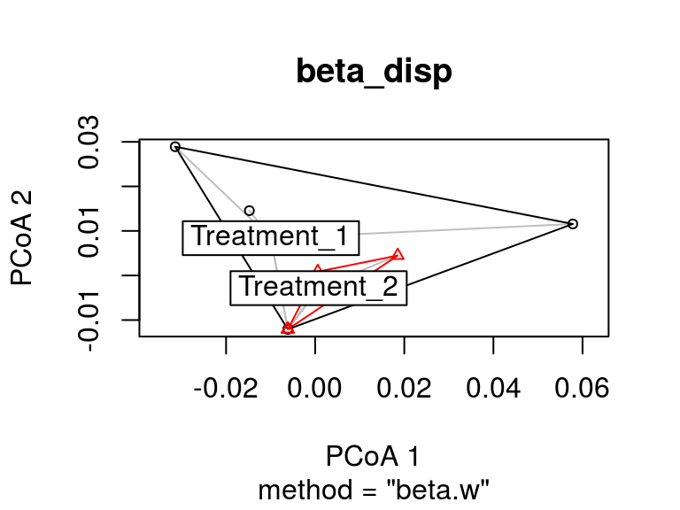

[output not shown]

```r
# Look at the beta diversity between two randomly-generated communities

beta_div = betadiver(community_matrix, method = "w")
beta_disp = betadisper(beta_div, treat)
plot(beta_disp)
```

### WEEK 13

- Importing and manipulating DNA sequence data
  - Bioconductor
  - Sequence data
  - Biostrings
- Phylogenetics examples
  - Sequence alignment
  - Tree building
  - Taxonomic assignment

```r
# Packages used (partial list):
Bioconductor
ape
biostrings

# Functions covered (parital list):

To be decided...
```

```r
# Assign a DNA sequence to a special DNAString object
Seq_1 = DNAString("TCTCTTCGCCGCCGCTGGCCTTGCCGCTGCTGCTCCTCTCGAGTCTCGCCAGGACACCGCATCCTGCCCTGTCACCACTGAGGGTGACTACGTCTGG")

reverseComplement(Seq_1) # Gives reverse-compliment of a DNA sequence
```

```
##   97-letter "DNAString" instance
## seq: CCAGACGTAGTCACCCTCAGTGGTGACAGGGCAG...GCAGCAGCGGCAAGGCCAGCGGCGGCGAAGAGA
```

### WEEK 14

- Command-line tools
- BASH
- compression
- grep, sed, find, |, gzip/gunzip, tar, mv, cp, mkdir, etc.

### WEEK 15

- Data management
- Reporting
- Rmd

  Skills Test 4 (final):
  - Command-line data access and manipulation
  - Writing a script to
    - import specific data
    - tidy and normalize data
    - subset and group
    - test hypotheses
    - create intuitive plots that include test statistics
  - Save script as readable report

**This document was constructed entirely within R as an R-markdown (Rmd) file.**

The complete code for this document can be found online [HERE](https://raw.githubusercontent.com/gzahn/Data_Course/master/Rough_Course_Outline.rmd) at the [Course GitHub repository](https://github.com/gzahn/Data_Course)